# The genetic architecture of pilonidal sinus disease

A multi-biobank, multi-ancestry meta-GWAS and its overlap with the follicular occlusion disorders

João Cavalcante

UFRN

2026-10-19

## Pilonidal sinus disease (PSD)

- Chronic inflammation of the natal cleft: hair-filled sinus tracts and recurrent abscesses
- Incidence 26 per 100,000; 2.2× more common in men; presents around age 20; family history in 38% (Søndenaa et al. 1995)
- Acquired-disease model: hair insertion causes the sinus and its recurrence (Karydakis 1992); overweight, local trauma and sedentary work are common (Søndenaa et al. 1995)
- Recurrence depends on surgical technique and follow-up: < 1% at 2 years after flap or Karydakis/Bascom repair, up to 68% at 20 years after midline closure (Stauffer et al. 2018)
- Positive family history: earlier onset and more long-term recurrence (52% vs 28% at 25 years) (Doll et al. 2009), so the disease is partly **heritable**

**Follicular occlusion tetrad**

PSD is grouped with **hidradenitis suppurativa (HS)**, acne conglobata and dissecting cellulitis of the scalp (Vasanth and Chandrashekar 2014)

Shared feature: follicular occlusion and rupture

## What was known about PSD genetics

| Study | Design | Loci |
| --- | --- | --- |
| Roberson et al. (2024) | GWAS, UKB + FinnGen + Penn Medicine (2,835 cases, European only) | 5 loci: *HDAC9/TWIST1*, *TBX15/WARS2*, *PRKAR1B*, *NEK9/EIF2B2/GPATCH2L*, *RP11-293M10.1*. Also rg with male-pattern baldness and rare *TCHH* variants (OR 4.8) |
| FinnGen R12 (Kurki et al. 2023) | Single biobank (Open Targets credible sets) | *DKK1/MBL2*, *TCHH* (epidermal differentiation complex), chr1:27 Mb |
| UK Biobank WGS (UK Biobank Whole-Genome Sequencing Consortium 2025) | Rare-variant credible sets (public summary statistics) | *CHRM3*, *RNFT2* |
| Klein et al. (2025) | Focused UKB dermatology GWAS | *TTK* (rare coding) |

**Gaps**

- European ancestry only; at most 2,835 cases
- No comparison with HS or acne, and no locus-level test of the hair and body-shape links
- No gene- or pathway-level interpretation of the polygenic signal

## Aims

1. **Discover** PSD risk loci with a multi-biobank, multi-ancestry meta-GWAS and fine-map them
2. **Partition** what PSD shares with HS, acne, balding and body shape, both genome-wide and locus by locus
3. **Prioritise** candidate effector genes and test which pathways carry the polygenic signal

## Data: PSD summary statistics

| Cohort | Ancestry | Cases | Controls | Source |
| --- | --- | --- | --- | --- |
| Million Veteran Program (Verma, Huffman, et al. 2024) | EUR + AFR + AMR | 2,073 | 629,531 | GCST90480439 |
| ↳ MVP, European subset (EUR meta only) | EUR | 1,433 | 448,820 | GCST90478766 |
| UK Biobank, WGS (UK Biobank Whole-Genome Sequencing Consortium 2025) | EUR | 1,466 | 456,974 | GCST90473908 |
| FinnGen R13 (Kurki et al. 2023) | FIN | 3,872 | 468,418 | L12_PILONIDALCYST |
| Genes & Health, exome (Kim et al. 2026; Finer et al. 2020) | SAS | 457 | 43,569 | GCST90727025 |
| **META_ALL** | all | **7,868** | **1.6 M** |  |
| **META_EUR** | EUR + FIN | **6,771** | **1.37 M** |  |

- All public summary statistics: GWAS Catalog (Sollis et al. 2023) and FinnGen public release
- About 2.8× the cases of the previous largest PSD GWAS

## Data: comparator traits

- **HS**: MVP + UKB + FinnGen, EUR + AFR (3,941 cases) (Peacker et al. 2026); FinnGen R13 (1,453 cases)
- **Acne**: FinnGen R13 (4,812 cases); Teder-Laving et al. (2024) (34,422 cases)
- **Balding**: UKB men, hair pattern 1 (Jiang et al. 2021) and pattern 4 (Neale lab UKB GWAS)
- **BMI, WHR adj. BMI**: GIANT + UKB (Pulit et al. 2019)
- **Alopecia areata**: FinnGen R13
- **eQTL**: GTEx v8 skin, fibroblasts and adipose tissue, via the eQTL Catalogue (Kerimov et al. 2021; GTEx Consortium 2020)

## Methods

### 1 · Discovery

- Harmonize to GRCh38 (all coordinates in this talk are GRCh38); MAF ≥ 1%; multi-allelic sites removed; variant present in ≥ 2 cohorts
- Fixed-effect inverse-variance meta-analysis in METAL (Willer, Li, and Abecasis 2010)
- Distinct loci (±500 kb), labeled known or novel against prior articles
- LDSC intercept correction (Bulik-Sullivan et al. 2015)
- Leave-FinnGen-out check; random effects at heterogeneous loci
- Fine-mapping: ABF (Wakefield 2009) + SuSiE-RSS with UK Biobank LD (Zou et al. 2022)

### 2 · Shared genetics

- Genome-wide: LDSC rg
- Joint model: Genomic SEM
- Local: LAVA, ~1 Mb blocks
- Variant: coloc
- How much of the signal is shared with HS, acne, balding and adiposity?

### 3 · Genes and pathways

- eQTL coloc with GTEx v8 skin, fat and fibroblasts (Kerimov et al. 2021; GTEx Consortium 2020)
- Locus-to-gene scoring
- Gene-level scores: MAGMA (de Leeuw et al. 2015)
- Gene sets: 6,717 GO BP and Reactome sets, MHC genes removed, Bonferroni

The **MHC** (chr6:25–34 Mb) is excluded from locus counts, colocalization, LAVA and gene sets, because its long-range LD inflates every gene-level method.

## Result 1: 25 risk loci, 19 novel

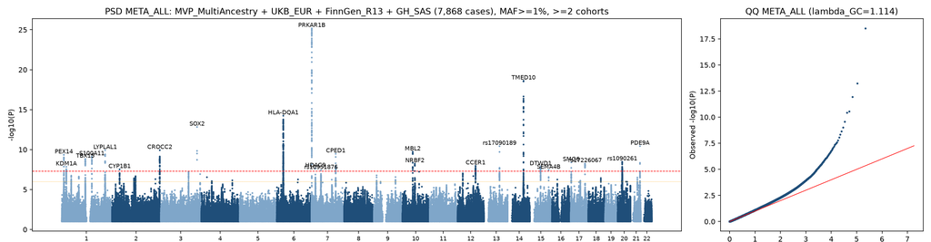

- **25 genome-wide significant loci outside the MHC: 6 known, 19 novel.** None of the 19 reaches significance in any single cohort.
- LDSC intercept 1.05 (ratio 0.25), so inflation is mostly polygenicity. 21 loci (15 novel) survive intercept correction.
- Not driven by one biobank: every novel locus keeps its direction with p < 0.05 in MVP + UKB alone.
- SNP heritability (liability scale) 13–15%; rg between biobanks 0.83 (MVP vs FinnGen).

## Fine-mapping highlights

| Locus | Top variant | PIP ABF | PIP SuSiE | Comment |
| --- | --- | --- | --- | --- |
| *SOX2* | rs1345417 | 1.00 | 0.99 | One-variant credible set |
| *PDE9A* | rs111363985 | 0.90–0.98 | 0.92 |  |
| chr13:73.4 Mb (*KLF5*) | rs17090189 | 0.65–0.81 | 0.79 | Same lead variant as HS |
| *WNT10A* | rs121908120 (p.Phe228Ile) | 0.45–0.57 | 0.73 | Protective missense, OR 0.54† |

- Hair-follicle development genes lie near several loci: *SOX2*, *SOX9*, *WNT10A*, *DKK1*, *TWIST1*, *TBX15*

† Suggestive after LDSC-intercept correction. ABF: META_EUR and META_ALL. SuSiE-RSS: META_EUR with UK Biobank European LD, with LD-mismatch diagnostics.

## Result 2: shared genetics with other traits

[output not shown]

Details in backup slides. PSD META_EUR; MHC excluded. Joint models: PSD ~ HS + BMI, and PSD ~ HS + acne + BMI + WHR + balding.

## Result 3: gene sets (MAGMA, MHC-free)

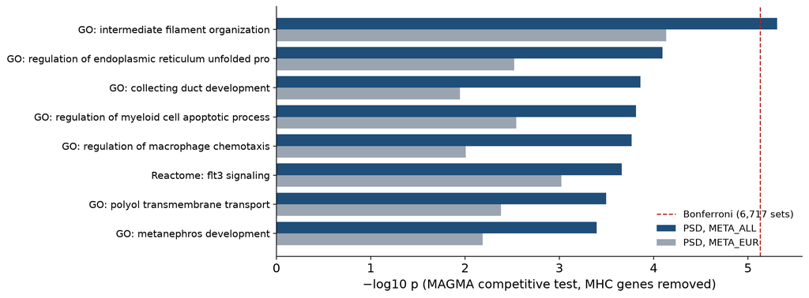

- One set passes Bonferroni across 6,717: **intermediate filament organisation** (74 genes, p = 5×10⁻⁶, p<sub>Bonf</sub> = 0.03, META_ALL)
- Driven by *TCHH* and hair and inner root sheath keratins (*KRT31*, *KRT35*, *KRT36*, *KRT40*, *KRT71*), none genome-wide significant; holds without the *TCHH* region (p = 3×10⁻⁵)
- Same direction in META_EUR (p = 7×10⁻⁵, not significant); not associated with HS, acne or BMI (p > 0.6)
- **No immune pathway enriched outside the MHC**

## Result 4: gene expression (eQTL colocalization)

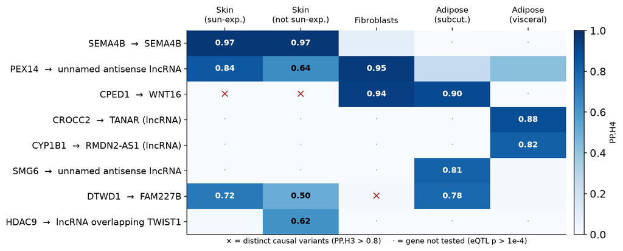

- 25 loci × 5 GTEx v8 tissues from the eQTL Catalogue (Kerimov et al. 2021; GTEx Consortium 2020); 6 loci share a causal variant with at least one gene
- *SEMA4B*: the PSD risk allele **raises *SEMA4B* expression in skin** (PP.H4 0.97, resolved to one SNP, rs34560261). The same SNP is the likely causal acne variant (Petridis et al. 2018).
- *CPED1* → *WNT16*: the risk allele raises *WNT16* in fibroblasts and fat; in skin, a different variant drives *WNT16*
- No eQTL support for the developmental genes (*SOX2*, *SOX9*, *TBX15*, *DKK1*, *KLF5*): adult bulk tissue misses developmental regulation

## Locus-to-gene: which genes are supported?

| Strongest evidence | Loci | Prioritised gene(s) |
| --- | --- | --- |
| Coding variant (PIP ≥ 0.1) or eQTL coloc, protein-coding gene | 3 | *SEMA4B*‡ (skin eQTL) · *WNT16* at *CPED1* (fibroblast eQTL) · *WNT10A*‡ (p.Phe228Ile) |
| eQTL coloc with a lncRNA only | 4 | *CROCC2* (TANAR) · *PEX14* (antisense) · *SMG6* (antisense) · *CYP1B1*‡ (RMDN2-AS1) |
| Two or more weaker lines | 8 | *PRKAR1B* · *TMED10* · *SOX2* · *TCHH* · *TBX15* · *FAM227B* · *KDM1A* · *HDAC9* |
| One line (mostly proximity) | 10 | *PDE9A* · *LYPLAL1* · *DKK1*/*MBL2* · *NRBF2* · *CCER1* · *MRPS22*‡ · gene deserts: *SOX9*, *KLF12*†, *PAX1*, *TNS3* |

- Gene score: nearest (+1), top MAGMA gene (+1), coding variant in the credible set (+1/+2), eQTL coloc (+1/+2), Open Targets L2G (+1). Functional evidence for a protein-coding gene outranks proximity.
- **Only 3 of 25 loci have a functional effector gene.** The developmental genes (*SOX2*, *SOX9*, *DKK1*) rest on proximity plus locus-level sharing with balding or HS.
- 4 loci are gene deserts (nearest gene 250–600 kb away): their targets need developmental or skin-specific regulatory data.

† chr13:73.4 Mb: the nearest protein-coding gene is *KLF12* (254 kb); “*KLF5* region” follows the HS GWAS naming (Sun et al. 2023). ‡ p = 5–8×10⁻⁸ after LDSC-intercept correction (suggestive).

## Functional interpretation: two genetic axes

### Hair (shared with balding)

- *SOX2* marks the dermal papilla cells that set hair-follicle type (Driskell et al. 2009)
- *WNT10A*: the protective allele (p.Phe228Ile, OR 0.54) is a known ectodermal-dysplasia allele (ClinVar 4462); loss of *WNT10A* gives sparse hair (Adaimy et al. 2007)
- *TCHH* builds the hair shaft; its mutations cause uncombable hair (Ü. Basmanav et al. 2016). Hair-shaft and inner root sheath keratins are enriched genome-wide
- *DKK1* is induced by androgens in balding dermal papilla (Kwack et al. 2008); *HDAC9/TWIST1* is a balding locus (Roberson et al. 2024), where the PSD risk allele raises a skin lncRNA overlapping *TWIST1* (suggestive eQTL coloc)

**→ Inherited hair-shaft and follicle traits, partly androgen-driven, may make hairs likelier to penetrate the natal cleft (Karydakis 1992). This could help explain the male excess.**

### Follicular epithelium (shared with HS and acne)

- *KLF5* region: the **same lead SNP (rs17090189) as the HS GWAS** (Sun et al. 2023)
- *SOX9* region: an HS locus (Sun et al. 2023); *SOX9* builds the outer root sheath and hair stem-cell niche (Vidal et al. 2005)
- *SEMA4B* and *WNT10A* are acne loci; the *SEMA4B* causal variant sits in a p63 binding site (Petridis et al. 2018)
- *WNT16* drives keratinocyte proliferation (Teh et al. 2007)

**→ The PSD–HS–acne overlap points to the pilosebaceous epithelium, giving a genetic basis for “follicular occlusion”.**

## A working model

```
flowchart LR
  G["PSD genetic<br/>liability"] --> H["Hair traits<br/>SOX2 · WNT10A · TCHH<br/>DKK1 · HDAC9/TWIST1"]
  G --> F["Follicular epithelium<br/>SOX9 · KLF5 · SEMA4B<br/>WNT16 · PRKAR1B"]
  H --> I["Hair insertion<br/>in the natal cleft"]
  F --> O["Follicular occlusion<br/>and rupture"]
  I --> S["Sinus tract"]
  O --> S
  S --> X["Secondary inflammation<br/>and infection"]
  B["Higher BMI"] -. "via HS-shared<br/>liability" .-> F
```

- Hair axis: shared with balding, PSD-specific relative to HS. Epithelial axis: shared with HS and acne.
- Outside the MHC, no immune pathway is enriched: consistent with inflammation being secondary, although genetic data cannot establish the order of events
- Testable predictions: hair-shaft properties by genotype; *SEMA4B*, *KLF5* and *SOX9* enhancer activity in follicular keratinocytes

## Limitations and next steps

**Limitations**

- About 86% of cases are of European ancestry
- The HS comparator shares cohorts with PSD. This is handled with LDSC intercepts, and the non-overlap rg is 0.54.
- ICD-code phenotypes
- LD-reference mismatch in fine-mapping
- Between-cohort heterogeneity at 4 loci (*DKK1/MBL2*, *TCHH*, *KDM1A*, *HDAC9*; I² 67–81%); random effects as sensitivity analysis
- 19 novel loci reach significance only in the meta-analysis
- No fully independent replication cohort yet

**Next steps**

- coloc-SuSiE at multi-signal loci (*PEX14*, *SEMA4B*)
- Manuscript submission (EJHG)

## References

Adaimy, L. et al. 2007. “Mutation in WNT10A Is Associated with an Autosomal Recessive Ectodermal Dysplasia: The Odonto-Onycho-Dermal Dysplasia.” *American Journal of Human Genetics* 81: 821–28.

Bulik-Sullivan, B. K., P.-R. Loh, H. K. Finucane, et al. 2015. “LD Score Regression Distinguishes Confounding from Polygenicity in Genome-Wide Association Studies.” *Nature Genetics* 47: 291–95.

de Leeuw, C. A., J. M. Mooij, T. Heskes, and D. Posthuma. 2015. “MAGMA: Generalized Gene-Set Analysis of GWAS Data.” *PLoS Computational Biology* 11: e1004219.

Doll, D., E. Matevossian, K. Wietelmann, T. Evers, et al. 2009. “Family History of Pilonidal Sinus Predisposes to Earlier Onset of Disease and a 50% Long-Term Recurrence Rate.” *Diseases of the Colon & Rectum* 52: 1610–15.

Driskell, R. R. et al. 2009. “Sox2-Positive Dermal Papilla Cells Specify Hair Follicle Type in Mammalian Epidermis.” *Development* 136: 2815–23.

Finer, S., H. C. Martin, A. Khan, et al. 2020. “Cohort Profile: East London Genes & Health (ELGH), a Community-Based Population Genomics and Health Study in British Bangladeshi and British Pakistani People.” *International Journal of Epidemiology* 49: 20–21i.

GTEx Consortium. 2020. “The GTEx Consortium Atlas of Genetic Regulatory Effects Across Human Tissues.” *Science* 369: 1318–30.

Jiang, L., Z. Zheng, H. Fang, and J. Yang. 2021. “A Generalized Linear Mixed Model Association Tool for Biobank-Scale Data.” *Nature Genetics* 53: 1616–21.

Karydakis, G. E. 1992. “Easy and Successful Treatment of Pilonidal Sinus After Explanation of Its Causative Process.” *Australian and New Zealand Journal of Surgery* 62: 385–89.

Kerimov, N., J. D. Hayhurst, K. Peikova, et al. 2021. “A Compendium of Uniformly Processed Human Gene Expression and Splicing Quantitative Trait Loci.” *Nature Genetics* 53: 1290–99.

Kim, H. I., C. DeBoever, K. Walter, et al. 2026. “Exome Sequencing and Analysis of 44,028 British South Asians Enriched for High Autozygosity.” *Nature Genetics* 58: 821–30.

Klein, J. C. et al. 2025. “Identification of Associations with Dermatologic Diseases Through a Focused GWAS of the UK Biobank.” *JID Innovations* 5 (1): 100322.

Kurki, M. I., J. Karjalainen, P. Palta, et al. 2023. “FinnGen Provides Genetic Insights from a Well-Phenotyped Isolated Population.” *Nature* 613: 508–18.

Kwack, M. H. et al. 2008. “Dihydrotestosterone-Inducible Dickkopf 1 from Balding Dermal Papilla Cells Causes Apoptosis in Follicular Keratinocytes.” *Journal of Investigative Dermatology* 128: 262–69.

Peacker, B. L., L. Ly, J. C. Hwang, et al. 2026. “Multiomics Analyses Prioritize Disease Genes and Pathways in Hidradenitis Suppurativa.” *Journal of Investigative Dermatology* 146: 1807–1815.e2.

Petridis, C. et al. 2018. “Genome-Wide Meta-Analysis Implicates Mediators of Hair Follicle Development and Morphogenesis in Risk for Severe Acne.” *Nature Communications* 9: 5075.

Pulit, S. L., C. Stoneman, A. P. Morris, et al. 2019. “Meta-Analysis of Genome-Wide Association Studies for Body Fat Distribution in 694 649 Individuals of European Ancestry.” *Human Molecular Genetics* 28: 166–74.

Roberson, J. L. et al. 2024. “Genome-Wide Association Study Identifies Genes for Hair Growth and Patterning Are Associated with Pilonidal Disease.” *Diseases of the Colon & Rectum* 67 (9): 1149–57.

Sollis, E., A. Mosaku, A. Abid, et al. 2023. “The NHGRI-EBI GWAS Catalog: Knowledgebase and Deposition Resource.” *Nucleic Acids Research* 51: D977–85.

Søndenaa, K., E. Andersen, I. Nesvik, and J. A. Søreide. 1995. “Patient Characteristics and Symptoms in Chronic Pilonidal Sinus Disease.” *International Journal of Colorectal Disease* 10: 39–42.

Stauffer, V. K., M. M. Luedi, P. Kauf, et al. 2018. “Common Surgical Procedures in Pilonidal Sinus Disease: A Meta-Analysis, Merged Data Analysis, and Comprehensive Study on Recurrence.” *Scientific Reports* 8: 3058.

Sun, Q. et al. 2023. “Genetic Variants Associated with Hidradenitis Suppurativa.” *JAMA Dermatology* 159: 930–38.

Teder-Laving, M. et al. 2024. “Genome-Wide Meta-Analysis Identifies Novel Loci Conferring Risk of Acne Vulgaris.” *European Journal of Human Genetics* 32: 1136–43.

Teh, M. T. et al. 2007. “Role for WNT16B in Human Epidermal Keratinocyte Proliferation and Differentiation.” *Journal of Cell Science* 120: 330–39.

Ü. Basmanav, F. B. et al. 2016. “Mutations in Three Genes Encoding Proteins Involved in Hair Shaft Formation Cause Uncombable Hair Syndrome.” *American Journal of Human Genetics* 99: 1292–1304.

UK Biobank Whole-Genome Sequencing Consortium. 2025. “Whole-Genome Sequencing of 490,640 UK Biobank Participants.” *Nature* 645: 692–701.

Vasanth, V., and B. S. Chandrashekar. 2014. “Follicular Occlusion Tetrad.” *Indian Dermatology Online Journal* 5: 491–93.

Verma, A., J. E. Huffman, et al. 2024. “Diversity and Scale: Genetic Architecture of 2068 Traits in the VA Million Veteran Program.” *Science* 385: eadj1182.

Vidal, V. P. et al. 2005. “Sox9 Is Essential for Outer Root Sheath Differentiation and the Formation of the Hair Stem Cell Compartment.” *Current Biology* 15: 1340–51.

Wakefield, J. 2009. “Bayes Factors for Genome-Wide Association Studies: Comparison with P-Values.” *Genetic Epidemiology* 33: 79–86.

Willer, C. J., Y. Li, and G. R. Abecasis. 2010. “METAL: Fast and Efficient Meta-Analysis of Genomewide Association Scans.” *Bioinformatics* 26: 2190–91.

Zou, Y., P. Carbonetto, G. Wang, and M. Stephens. 2022. “Fine-Mapping from Summary Data with the ‘Sum of Single Effects’ Model.” *PLoS Genetics* 18: e1010299.

# Backup

## Backup: PSD is genetically closest to HS

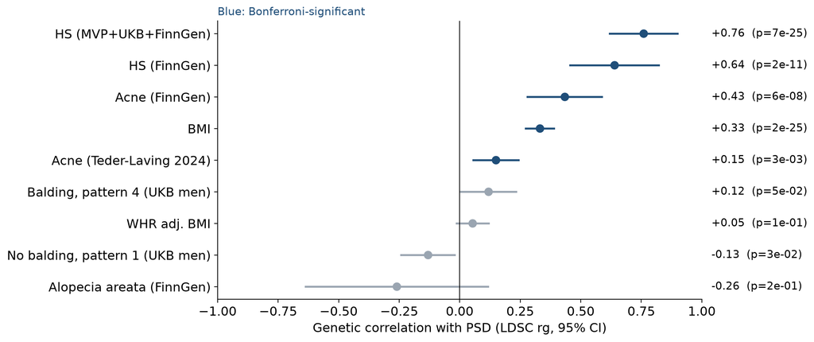

- HS rg = 0.76, and 0.54 when the cohorts don’t overlap (MVP PSD vs FinnGen HS)
- Acne 0.15–0.43 · BMI 0.33 · PSD risk tracks balding (weak; first reported by Roberson et al. (2024)) · WHR adj. BMI and alopecia areata not significant

## Backup: Genomic SEM: HS explains the BMI link

| Model | Result |
| --- | --- |
| PSD ~ HS + BMI | HS **β = 0.75** (p = 1×10⁻⁸) · BMI β = 0.01 (p = 0.89) |
| PSD ~ HS + acne + BMI + WHR + balding | HS **0.73** · no-balding **−0.25** (p = 1×10⁻⁵) · others not significant |
| Common factor (PSD, HS, acne) | PSD loading **0.94**; residual variance 0.12 (SE 0.26) |

- PSD’s genetic link to BMI runs **through the liability it shares with HS**, not through obesity itself
- A separate **hair-patterning** component remains: PSD risk goes with balding
- Most of PSD’s common-variant liability is a follicular-occlusion factor

## Backup: shared causal variants (colocalization)

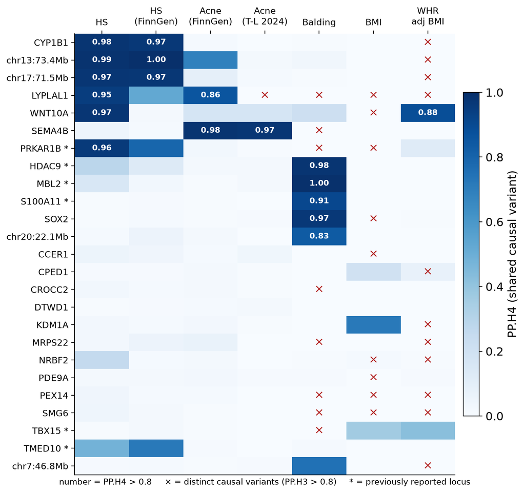

coloc.abf, ±500 kb, p₁₂ = 5×10⁻⁶; shared = PP.H4 > 0.8

## Backup: LAVA: local genetic correlation

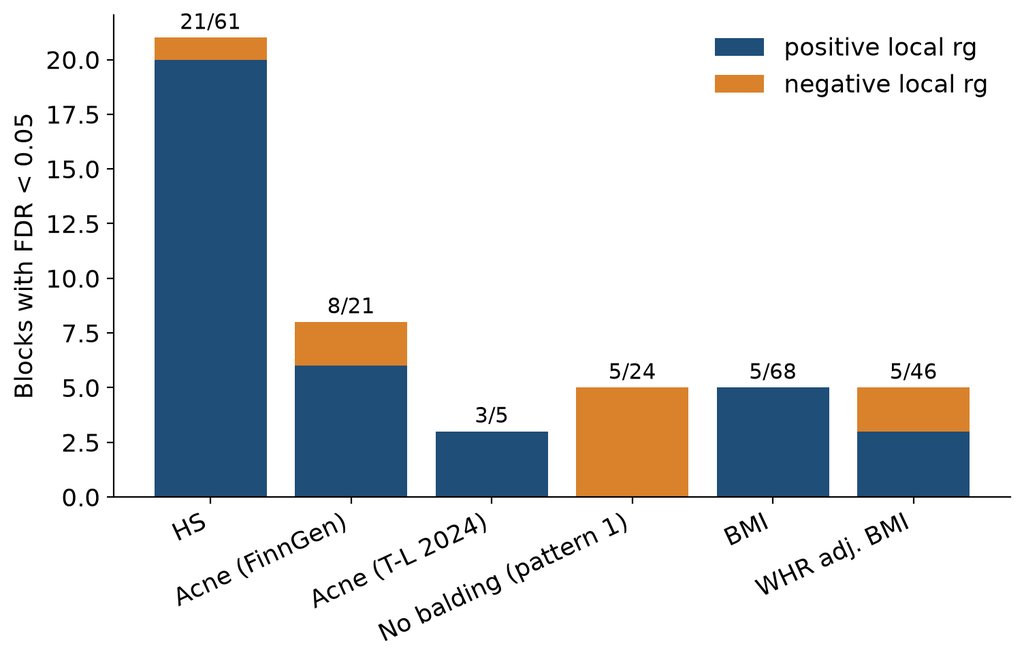

FDR < 0.05 (Benjamini–Hochberg)